# 04_ltv_bgnbd_gammagamma

### Faz 4.1: BG/NBD Modeli ile İşlem Sıklığı (Frequency) Tahmini

#### İş Gerekçesi

Müşterilerin gelecekteki satın alma frekanslarını tahmin etmek ve "bu müşteri sistemde hala aktif mi?" (probability alive) sorusuna matematiksel bir yanıt bulmak.

#### Teknik Detay ve Karar Gerekçeleri

Beta-Geometric / Negative Binomial Distribution (BG/NBD) modeli `lifetimes` kütüphanesi kullanılarak eğitiliyor. Aşırı öğrenmeyi (overfitting) engellemek adına L2 regülarizasyonu (penalizer_coef=0.01) uygulanarak 90 günlük (çeyreklik) satın alma beklentileri hesaplanıyor.

**Teknik Karar:** Modelin çıktıları sadece salt tahmin olarak bırakılmamış, "Probability Alive" ve "Beklenen Alışveriş" matrisleriyle görselleştirilmiştir. Model parametreleri (a < b) incelendiğinde müşterilerin genel olarak erken terk (churn) etmeme eğiliminde olduğu istatistiksel olarak doğrulanmıştır.

```
BG/NBD modeli eğitiliyor...
<lifetimes.BetaGeoFitter: fitted with 4234 subjects, a: 0.09, alpha: 72.61, b: 0.73, r: 1.25>

90 GÜNLÜK TAHMİN ÖZETİ
==================================================
Ortalama beklenen alışveriş : 1.14
Medyan beklenen alışveriş   : 0.75
Hâlâ aktif olma ort. olasılık: %79.4
```

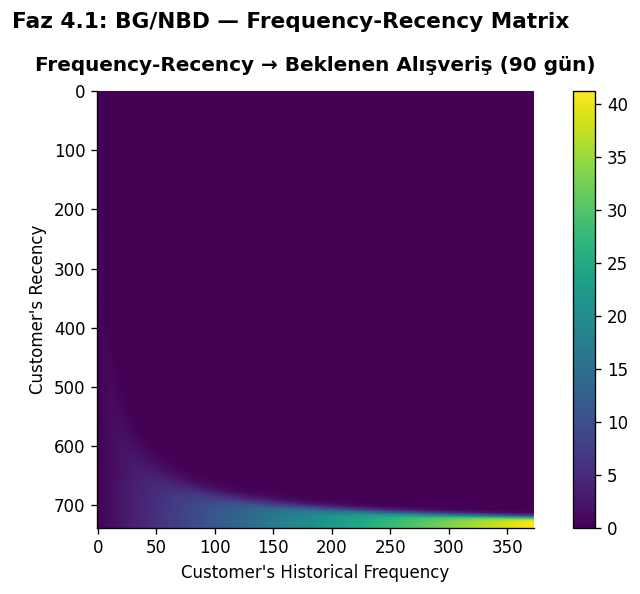

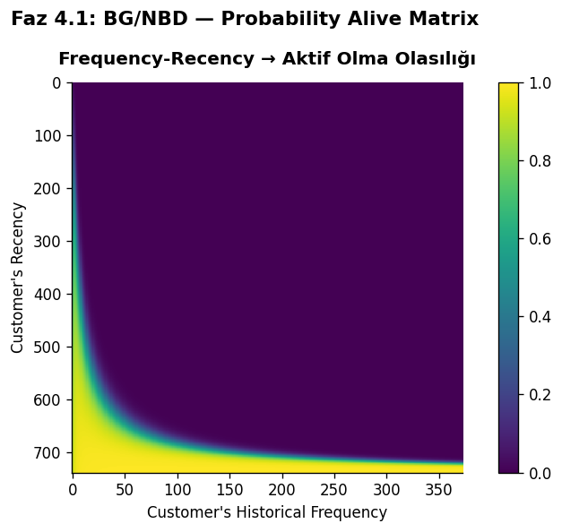

```
BG/NBD parametre yorumu:
  r=1.25, alpha=72.61  → satın alma hızı dağılımı
  a=0.09, b=0.73          → churn hızı dağılımı
  a < b → müşterilerin büyük çoğunluğu erken churnetmiyor, aktif kalma eğilimi yüksek
```

```python
# ═══════════════════════════════════════════════════════════════════
# FAZ 4.1: BG/NBD MODELİ — Gelecek Satın Alma Tahmini
# ═══════════════════════════════════════════════════════════════════
# BG/NBD (Beta-Geometric / Negative Binomial Distribution):
#   - Her müşteri için beklenen satın alma sayısını tahmin eder
#   - "Bu müşteri hâlâ aktif mi?" sorusunu olasılıksal yanıtlar
#   - Girdi: frequency, recency, T (ham gün cinsinden)
#
# Penalizer: L2 regularization — küçük başla, fit stabilitesini izle.

from lifetimes import BetaGeoFitter, GammaGammaFitter
from lifetimes.plotting import (plot_frequency_recency_matrix,
                                plot_probability_alive_matrix)

print("BG/NBD modeli eğitiliyor...")

bgf = BetaGeoFitter(penalizer_coef=0.01)
bgf.fit(
    frequency      = ltv_gg['frequency'],
    recency        = ltv_gg['recency'],
    T              = ltv_gg['T']
)

print(bgf)
print()

# ── 90 günlük satın alma tahmini ─────────────────────────────────
T_PREDICT = 90

ltv_gg['predicted_purchases_90d'] = bgf.conditional_expected_number_of_purchases_up_to_time(
    T_PREDICT,
    ltv_gg['frequency'],
    ltv_gg['recency'],
    ltv_gg['T']
)

ltv_gg['prob_alive'] = bgf.conditional_probability_alive(
    ltv_gg['frequency'],
    ltv_gg['recency'],
    ltv_gg['T']
)

print(f"90 GÜNLÜK TAHMİN ÖZETİ")
print("=" * 50)
print(f"Ortalama beklenen alışveriş : {ltv_gg['predicted_purchases_90d'].mean():.2f}")
print(f"Medyan beklenen alışveriş   : {ltv_gg['predicted_purchases_90d'].median():.2f}")
print(f"Hâlâ aktif olma ort. olasılık: %{ltv_gg['prob_alive'].mean()*100:.1f}")
print()


# ── Görselleştirme (lifetimes plotting bug workaround) ────────────
fig1, ax1 = plt.subplots(figsize=(7, 5))
plt.figure(fig1.number)
plot_frequency_recency_matrix(bgf, T=T_PREDICT)
ax1 = plt.gca()
ax1.set_title('Frequency-Recency → Beklenen Alışveriş (90 gün)',
              fontweight='bold', pad=12)
plt.suptitle('Faz 4.1: BG/NBD — Frequency-Recency Matrix',
             fontsize=13, fontweight='bold')
plt.tight_layout()
plt.show()

fig2, ax2 = plt.subplots(figsize=(7, 5))
plt.figure(fig2.number)
plot_probability_alive_matrix(bgf)
ax2 = plt.gca()
ax2.set_title('Frequency-Recency → Aktif Olma Olasılığı',
              fontweight='bold', pad=12)
plt.suptitle('Faz 4.1: BG/NBD — Probability Alive Matrix',
             fontsize=13, fontweight='bold')
plt.tight_layout()
plt.show()

print("BG/NBD parametre yorumu:")
print(f"  r={bgf.params_['r']:.2f}, alpha={bgf.params_['alpha']:.2f}  → satın alma hızı dağılımı")
print(f"  a={bgf.params_['a']:.2f}, b={bgf.params_['b']:.2f}          → churn hızı dağılımı")
print(f"  a < b → müşterilerin büyük çoğunluğu erken churnetmiyor, aktif kalma eğilimi yüksek")
```

### Faz 4.2: Gamma-Gamma Modeli ile Müşteri Yaşam Boyu Değeri (CLTV)

#### İş Gerekçesi

Müşterilerin gelecekte bırakacağı ortalama sipariş değerini (AOV) tahmin etmek ve BG/NBD'nin işlem sıklığı tahmini ile birleştirerek 12 Aylık CLTV (Müşteri Yaşam Boyu Değeri) projeksiyonu oluşturmak.

#### Teknik Detay ve Karar Gerekçeleri

Öncelikle Gamma-Gamma modelinin en kritik varsayımı olan "İşlem sıklığı ile parasal değer arasında korelasyon yoktur" hipotezi Pearson korelasyonu ile test ediliyor. Varsayım sağlandıktan sonra model eğitiliyor ve aylık %1 iskonto oranı (discount rate) ile 12 aylık LTV hesaplanıyor.

**Teknik Karar:** LTV dağılımları doğası gereği aşırı sağa çarpık (right-skewed) olduğu için, görselleştirme aşamasında 99. persentil baz alınarak "clipping" işlemi yapılmış ve grafiklerin okunabilirliği artırılmıştır. Segment bazlı LTV özetleri, iş birimlerine doğrudan aksiyon alınabilir bir formatta sunulmuştur.

```
Frequency–Monetary korelasyon: 0.0288
✓ GG varsayımı karşılanıyor (|r| < 0.30)

Gamma-Gamma modeli eğitiliyor...
<lifetimes.GammaGammaFitter: fitted with 4234 subjects, p: 3.83, q: 0.34, v: 3.73>

12 AYLIK LTV ÖZETİ (4,234 müşteri)
=======================================================
count      4234.00
mean       2020.06
std        8161.97
min           0.00
25%         321.30
50%         826.52
75%        1879.88
max      238569.43

SEGMENT BAZINDA 12 AYLIK LTV
=======================================================
                    Ortalama LTV (£)  Medyan LTV (£)  Toplam LTV (£)
Segment
Şampiyonlar                  4826.64         2371.68      6347027.02
Gelişen Müşteriler           1098.52          735.38      1049089.34
Risk Altındakiler             759.12          540.88      1075668.54
Uyuyanlar                     148.33          121.47        81135.65
```

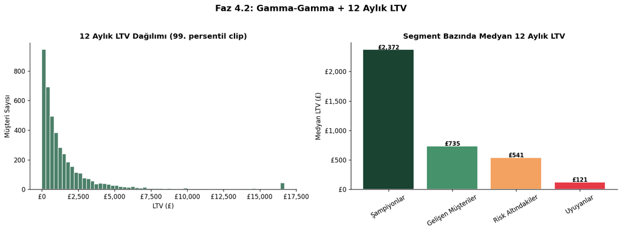

```python
# ═══════════════════════════════════════════════════════════════════
# FAZ 4.2: GAMMA-GAMMA MODELİ + LTV HESABI
# ═══════════════════════════════════════════════════════════════════
# Gamma-Gamma: her alışverişte harcanan miktarı modelliyor.
# Varsayım: frequency ve monetary_value arasında korelasyon olmamalı.
# Önce korelasyonu kontrol et — ihlal varsa yorumda belirt.
#
# LTV = BG/NBD tahmini (işlem sayısı) × GG tahmini (işlem başına değer)
# Zaman ufku: 12 ay (365 gün), discount_rate=0.01/ay (yıllık ~12.7%)

corr = ltv_gg[['frequency', 'monetary_value']].corr().iloc[0, 1]
print(f"Frequency–Monetary korelasyon: {corr:.4f}")
print(f"{'✓ GG varsayımı karşılanıyor (|r| < 0.30)' if abs(corr) < 0.30 else '⚠ Korelasyon yüksek — GG yorumuna dipnot ekle'}")
print()

# ── Gamma-Gamma fit ───────────────────────────────────────────────
print("Gamma-Gamma modeli eğitiliyor...")

ggf = GammaGammaFitter(penalizer_coef=0.01)
ggf.fit(
    frequency      = ltv_gg['frequency'],
    monetary_value = ltv_gg['monetary_value']
)
print(ggf)
print()

# ── Beklenen ortalama sipariş değeri ─────────────────────────────
ltv_gg['exp_avg_order_value'] = ggf.conditional_expected_average_profit(
    ltv_gg['frequency'],
    ltv_gg['monetary_value']
)

# ── 12 Aylık LTV ─────────────────────────────────────────────────
LTV_MONTHS   = 12
DISCOUNT_RATE = 0.01   # aylık

ltv_gg['LTV_12m'] = ggf.customer_lifetime_value(
    bgf,
    ltv_gg['frequency'],
    ltv_gg['recency'],
    ltv_gg['T'],
    ltv_gg['monetary_value'],
    time            = LTV_MONTHS,
    discount_rate   = DISCOUNT_RATE,
    freq            = 'D'
)

print(f"12 AYLIK LTV ÖZETİ ({len(ltv_gg):,} müşteri)")
print("=" * 55)
print(ltv_gg['LTV_12m'].describe().round(2).to_string())
print()

# Segment bilgisini ekle
seg_map = churn_base_df.set_index('Customer ID')['Segment']
ltv_gg['Segment'] = ltv_gg['Customer ID'].map(seg_map)

seg_ltv = ltv_gg.groupby('Segment')['LTV_12m'].agg(['mean','median','sum']).round(2)
seg_ltv.columns = ['Ortalama LTV (£)', 'Medyan LTV (£)', 'Toplam LTV (£)']
seg_ltv = seg_ltv.reindex(SEGMENT_ORDER)

print("SEGMENT BAZINDA 12 AYLIK LTV")
print("=" * 55)
print(seg_ltv.to_string())
print()

# ── Görselleştirme ───────────────────────────────────────────────
fig, axes = plt.subplots(1, 2, figsize=(14, 5))

# LTV dağılımı (log scale — sağ kuyruk baskılanır)
axes[0].hist(ltv_gg['LTV_12m'].clip(upper=ltv_gg['LTV_12m'].quantile(0.99)),
             bins=60, color='#2D6A4F', edgecolor='white', alpha=0.85)
axes[0].set_title('12 Aylık LTV Dağılımı (99. persentil clip)', fontweight='bold')
axes[0].set_xlabel('LTV (£)'); axes[0].set_ylabel('Müşteri Sayısı')
axes[0].xaxis.set_major_formatter(mticker.FuncFormatter(lambda x, _: f'£{x:,.0f}'))

# Segment bazında medyan LTV
colors_seg = [SEGMENT_COLORS[s] for s in seg_ltv.index]
bars = axes[1].bar(seg_ltv.index, seg_ltv['Medyan LTV (£)'],
                   color=colors_seg, edgecolor='white')
axes[1].set_title('Segment Bazında Medyan 12 Aylık LTV', fontweight='bold')
axes[1].set_ylabel('Medyan LTV (£)')
axes[1].tick_params(axis='x', rotation=30)
axes[1].yaxis.set_major_formatter(mticker.FuncFormatter(lambda x, _: f'£{x:,.0f}'))
for bar, v in zip(bars, seg_ltv['Medyan LTV (£)']):
    axes[1].text(bar.get_x() + bar.get_width()/2, v + 5,
                 f'£{v:,.0f}', ha='center', fontsize=9, fontweight='bold')

plt.suptitle('Faz 4.2: Gamma-Gamma + 12 Aylık LTV', fontsize=14, fontweight='bold', y=1.03)
plt.tight_layout()
plt.show()
```